# Literature Review

Sholto Maud

2015-03-10 13:12:00

## Abstract

This review covers the current legislative and technical approaches in Australia to the management of risk associated with energy production from unconventional resources. A brief historical survey is given to introduce the context of legislative discussion and various associated concepts, as a way of leading into the technical context, gap identification and recommendations for future work.

## Introduction

In the last few years unconventional energy (UE) production has been considered a significant potential economic resource for Australia. Unconventional energy in the Australian context, generally refers to gas held in shale or coal formations, along with what is known as “tight gas” (Taylor 2012, 7).

As noted by Professor Martin in the Committee for Economic Development of Australia (CEDA) report, property rights and water management are key issues for unconventional energy production (Taylor 2012, 5) . For water management specifically, Martin recommended that;

- Water allocation and licensing frameworks needed to be enhanced to include water that is produced, and consumed by UE producers
- Due to the potential for irreversible damage to environmental systems, including hydrological systems, UE producers develop a robust risk management framework with strong precautionary principles

Within the latter of these two concepts, Taylor recommended that UE users of water resources should carry the costs associated with any impacts of energy production activities, and that precautionary measures be scaled according to information available about impacts (Taylor 2012, 11).

The notion of scaling precautionary or corrective (so-called “make good”) actions in response to information is encompassed in the concept of Adaptive Environmental Management (AEM), and the associated Groundwater Model Multi Criteria Analysis (GMMCA). GMMCA is a Multi Criteria Analysis (MCA) enhanced to incorporate geological, hydrological, environmental and economic attributes (Beckers, Cook, and Butcher 2013). Both the GMMCA, and the concept of scaling precaution had the intent to enable regulatory flexibility, and to refine and improve risk mapping over time.

The attempt to integrate these enhancements in Australia has highlighted legislative and technical gaps. It is the intention of this review to identify the main gaps as noted in the literature, and within the technical community, and to posit potential solutions as a part of future research work.

## Critical Reviews

## Legislative Enhancements

## Risks

### Risk Assessment

In the Terms of Reference for Activity 5 of the CSG Feasibility Study, a hybrid Groundwater Model and Multi Criteria Analysis (GMMCA) risk assessment methodology was developed (Beckers, Cook, and Butcher 2013).

http://www5.austlii.edu.au/au/legis/qld/consol_act/wa200083/s418.html

### Make Good Measures

The gap identified by the literature appears to be the connection between GMMCA risk assessment and the make good measures.

http://www5.austlii.edu.au/au/legis/qld/consol_act/wa200083/s421.html

As a part of this flexibility, Beckers et al recommend that adaptive methodologies include the temporal aspect within risk assessment (2013, p.iii), with the ability to track long term effects. This type of recommendation implies a long term monitoring effort with associated hydrology data storage technologies for meta-data, and timeseries data. And in addition to these usual types of data, the temportal aspect of risk should also thereofre be stored.

## Technical Context

The prevailing Technical Context (TC) might be characterised by three different approaches to the task of providing a data system capable of meeting the requirements of risk management.

```
1. in-house technical
2. out-sourced vendor
3. hybrid
```

In #3, the hybrid situation, the data system is typically maintained by a team of subject experts together with a system administrator.

## Conclusions and Future Work

This review has focuses on the regulatory frameworks which have been concieved to provide effective management of the risks associated with Unconventional Energy production.

The design intent of the legislative concepts appears to necessitate a technical legislative framework to store and integrate many different dtata types over time. Such a framework is the main interest for future work. The three novel technical goals of that work envisiaged are;

1. Proof of concept for a technical framework, which enables;
2. The integration of the temporal component of risk into precautionary and adaptive measures, and
3. The integration of model uncertainty into the calculation of risk.

Coal Seam CSG exploration and production (hereafter, CSG operations) raise community concern due to the potential impacts on long-term food security, water resources, public health and individual property rights for the sake of mining royalties, economic growth and employment opportunities

## What is Risk?

Risk is the product of probability and consequence

## Types of Risk

Identified below are many different types of risk associated with different disciplines and contexts.

- Static vs Dynamic -> asset changing risk status over time
- Risk Intensity/Density -> analogy which might be used to incorporate uncertainty
- Technical/Operational
- Compliance/Legal
- Bus Factor
- Political/social -> social license
- Strategic
- Financial
- Model Risk
- Environmental/Health & Safety
- Data Quality Risk
- Reliability Engineering

## Methods of risk assessment

[output not shown]

### Hetrogenous methods

- Can we have one size fits all for a generic methodology?
- Do we need to select each risk method according to the scenario/context?

## Methods of risk management

| # | Method | Typical Industry |
| --- | --- | --- |
| 1. | Adaptive |  |
| 2. | Precautionary |  |

## Uncertainty and risk

1. How do we feed the uncertainty of our data into the associate risks
2. Are there different types of risk that need to be evaluated differently and fed into the risk calculation differently?
3. Is the typical risk matrix appropriate for all circumstances?
4. Should uncertainty only just accompany the risk as a second value?

## Gaps

## Technical methods

# Rmd testing

```r
# Quick summary
ranrw <- function(mu, sigma, p0=100, T=100) {
  cumprod(c(p0, 1 + (rnorm(n=T, mean=mu, sd=sigma)/100)))
}
prices2returns <- function(x) {
  100*diff(log(x))
}
returns2prices <- function(r, p0=100) {
  c(p0, p0 * exp(cumsum(r/100)))
}

cat("Simulate 25 points from a random walk starting at 1500 --\n")
```

```
## Simulate 25 points from a random walk starting at 1500 --
```

```r
p <- ranrw(0.05, 1.4, p0=1500, T=25)
    # gives you a 25-long series, starting with a price of 1500, where
    # one-period returns are N(0.05,1.4^2) percent.
print(p)
```

```
##  [1] 1500.000 1527.179 1532.356 1493.922 1494.456 1501.519 1499.727
##  [8] 1479.624 1476.649 1470.832 1500.593 1528.642 1553.815 1549.810
## [15] 1559.105 1539.598 1553.594 1552.702 1566.289 1575.605 1627.042
## [22] 1647.771 1668.896 1645.607 1686.202 1716.036
```

```r
cat("Convert to returns--\n")
```

```
## Convert to returns--
```

```r
r <- prices2returns(p)
print(r)
```

```
##  [1]  1.79572804  0.33841053 -2.54014474  0.03573802  0.47149704
##  [6] -0.11942850 -1.34951644 -0.20129202 -0.39468898  2.00323564
## [11]  1.85195670  1.63334282 -0.25810405  0.59793995 -1.25906090
## [16]  0.90497731 -0.05742275  0.87124550  0.59300751  3.21243167
## [21]  1.26599155  1.27386282 -1.40525765  2.43688436  1.75386684
```

```r
cat("Go back from returns to prices --\n")
```

```
## Go back from returns to prices --
```

```r
goback <- returns2prices(r, 1500)
print(goback)
```

```
##  [1] 1500.000 1527.179 1532.356 1493.922 1494.456 1501.519 1499.727
##  [8] 1479.624 1476.649 1470.832 1500.593 1528.642 1553.815 1549.810
## [15] 1559.105 1539.598 1553.594 1552.702 1566.289 1575.605 1627.042
## [22] 1647.771 1668.896 1645.607 1686.202 1716.036
```

```r
summary(r); sd(r)                       # summary statistics
```

```
##    Min. 1st Qu.  Median    Mean 3rd Qu.    Max.
## -2.5400 -0.2013  0.5930  0.5382  1.6330  3.2120
```

```
## [1] 1.344625
```

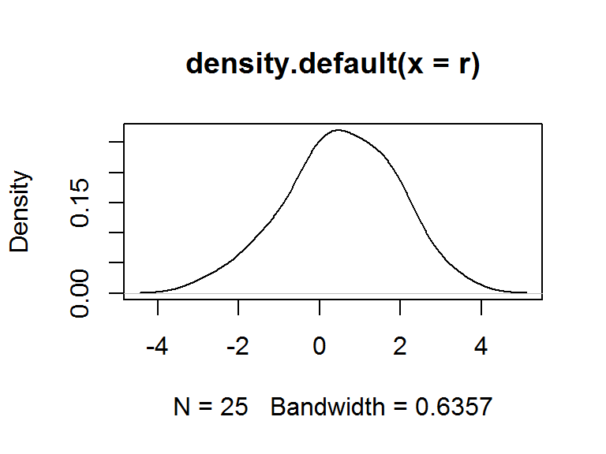

```r
plot(density(r))                        # kernel density plot
```

References

Beckers, Jos, Troy Cook, and Adam Butcher. 2013. “Groundwater Risks Associated with Coal Seam Gas Development in the Surat and Southern Bowen Basins - Final Report.” WorleyParsons Resource & Energy. https://www.dnrm.qld.gov.au/__data/assets/pdf_file/0013/106015/act-5-groundwater-risks-report-text.pdf.

Taylor, Nathan. 2012. “Australia’s Unconventional Energy Options.” Committee for Economic Development of Australia. http://adminpanel.ceda.com.au/FOLDERS/Service/Files/Documents/15347~cedaunconventionalenergyfinal.pdf.